# Inverse Fast Fourier Transform

1) **The Basics of Filtering in the Frequency Domain,**  
a) Convolution b) Sampling c) Quantization

2) **DFT : FFT**

[output not shown]

4) Image Interpolation and Image Resizing

5) Fourier Spectrum and Phase Spectrum of Images

6) Python Code for Implementing steps for Filtering in Frequency Domain

```python
import scipy.fftpack as fftim
from PIL import Image
import cv2
from google.colab.patches import cv2_imshow
import numpy, math
import numpy as np
import matplotlib.pyplot as plt
from scipy.interpolate import griddata
from skimage.io import imshow, imread
from skimage.transform import downscale_local_mean
```

### **1) The Basics of Filtering in the Frequency Domain**

```
Applying convolution operation of length  3  to the image
```

```
True
```

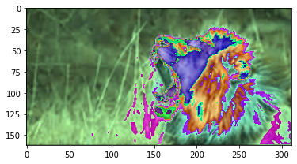

```python
# CONVOLUTION
from scipy import ndimage

image = cv2.imread("lion.jpeg") ## read image

conv_size = 3
print("Applying convolution operation of length ", conv_size, " to the image")

kernel = np.ones((conv_size, conv_size,3))  ## Create a kernel of fixed size
kernel = kernel/(conv_size*conv_size)

convolution = ndimage.convolve(image, kernel, mode='constant', cval=1.0)  ## Apply convolution operation


plt.imshow(convolution)
cv2.imwrite("Convolution.jpg", convolution)
```

```
image sampling
```

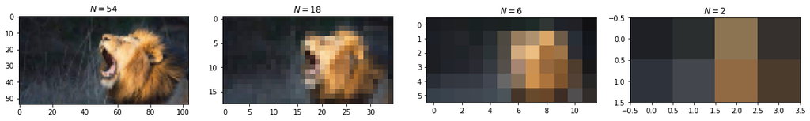

```python
# IMAGE SAMPLING

pi = imread('lion.jpeg')
print("image sampling")


factors = 3**np.arange(1, 5)
#representing of printing of plots
figure, axis = plt.subplots(1, len(factors), figsize=(20, 10))

for factor, ax in zip(factors, axis):
    image = downscale_local_mean(pi,
                 factors=(factor, factor, 1)).astype(int)     #using funation on different images
    ax.imshow(image)   #printing image
    ax.set_title('$N={}$'.format(image.shape[0])) #setting the title
    #cv2.imwrite('output1.jpeg',image)  #writing the image
```

```
image quantization
```

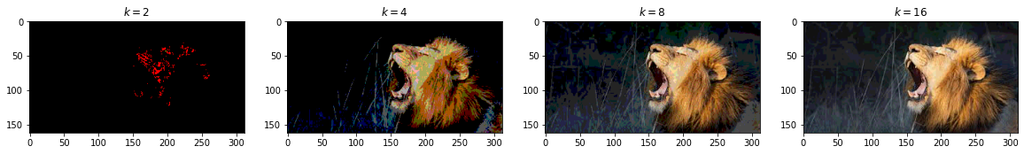

```python
# IMAGE QUANTIZATION

pi = imread('lion.jpeg')  #reading image
print("image quantization")

factors = 2**np.arange(1, 5)
figure, axis = plt.subplots(1, len(factors), figsize=(20, 10))  #representing of printing of plots
for k, ax in zip(factors, axis):   #using loop
    bins = np.linspace(0, pi.max(), k)
    image = np.digitize(pi, bins)
    image = (np.vectorize(bins.tolist().__getitem__)
                         (image-1).astype(int))  #vectorize each image
    ax.imshow(image)   #printing image
    ax.set_title('$k = {}$'.format(k)) #setting the tile for images
    #cv2.imwrite('output2.jpeg',image)  #writing the image
```

### **2) DFT : FFT**

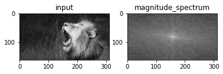

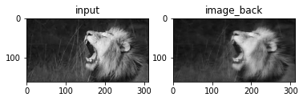

```python
##Applying the Fourier Tranformation
img =cv2.imread("lion.jpeg",0)
f=np.fft.fft2(img)
fshift=np.fft.fftshift(f)

#Applying the log transformation
magnitude_spectrum=20*np.log(np.abs(fshift))
plt.subplot(121),plt.imshow(img,'gray'),plt.title('input')
plt.subplot(122),plt.imshow(magnitude_spectrum,'gray'),plt.title('magnitude_spectrum')
plt.show()


rows,cols=img.shape
crows,ccols=np.int8(rows/2),np.int8(cols/2)
fshift[crows-50:crows+50,ccols-40:ccols+40]=0

##Applying the Inverse Fourier Tranformation
f_ishift=np.fft.ifftshift(fshift)
f_idft=np.fft.ifft2(f_ishift)
image_back=np.abs(f_idft)

#Plotting the outputs
plt.subplot(121),plt.imshow(img,'gray'),plt.title('input')
plt.subplot(122),plt.imshow(image_back,'gray'),plt.title('image_back')
plt.show()
```

### **4) Image Interpolation and Image Resizing**

```
Original
```

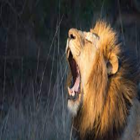

```
Half
```

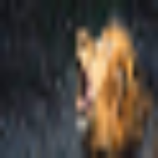

```
Bigger
```

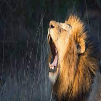

```
Interpolation Nearest
```

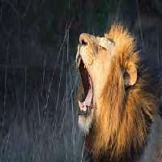

```
True
```

```python
from scipy.interpolate import griddata

# IMAGE RESIZING

image = cv2.imread('lion.jpeg')  #reading image
# Loading the image

half = cv2.resize(image, (0, 0), fx = 0.1, fy = 0.1)  #resizing the image of various sizes
bigger = cv2.resize(image, (1050, 1610))

stretch_near = cv2.resize(image, (780, 540),
			interpolation = cv2.INTER_NEAREST)

image = cv2.resize(image,(200,200))
half = cv2.resize(half,(200,200))
bigger = cv2.resize(bigger,(200,200))
stretch_near = cv2.resize(stretch_near,(200,200))

images =[image, half, bigger, stretch_near]

print("Original")
cv2_imshow(image)

print("\nHalf")
cv2_imshow(half)

print("\nBigger")
cv2_imshow(bigger)

print("\nInterpolation Nearest")
cv2_imshow(stretch_near)

cv2.imwrite("Half.jpeg",half)
cv2.imwrite("Bigger.jpeg",bigger)
cv2.imwrite("Interpolation Nearest.jpeg",stretch_near)
```

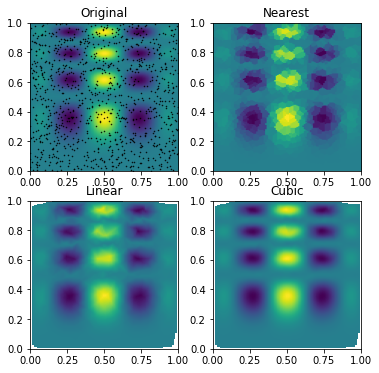

```python
#image interpolation

def func(x, y):
  return x*(1-x)*np.cos(4*np.pi*x) * np.sin(4*np.pi*y**2)**2

grid_x, grid_y = np.mgrid[0:1:100j, 0:1:200j]
points = np.random.rand(1000, 2)
values = func(points[:,0], points[:,1])


grid_z0 = griddata(points, values, (grid_x, grid_y), method='nearest')
grid_z1 = griddata(points, values, (grid_x, grid_y), method='linear')
grid_z2 = griddata(points, values, (grid_x, grid_y), method='cubic')


plt.subplot(221)
plt.imshow(func(grid_x, grid_y).T, extent=(0,1,0,1), origin='lower')
plt.plot(points[:,0], points[:,1], 'k.', ms=1)
plt.title('Original')

plt.subplot(222)
plt.imshow(grid_z0.T, extent=(0,1,0,1), origin='lower')
plt.title('Nearest')

plt.subplot(223)
plt.imshow(grid_z1.T, extent=(0,1,0,1), origin='lower')
plt.title('Linear')


plt.subplot(224)
plt.imshow(grid_z2.T, extent=(0,1,0,1), origin='lower')
plt.title('Cubic')

plt.gcf().set_size_inches(6, 6)
plt.show()
```

5) Fourier Spectrum and Phase Spectrum of Images

[figure not shown]

[figure not shown]

```python
img=cv2.imread('lenna.png')

# Fourier Spectrum of image
img_c2 = np.fft.fft2(img_c1)
plt.imshow(np.log(1+np.abs(img_c2)),"gray")
plt.title("spectrum")
plt.show()

# Phase Spectrum of Image
img = cv2.cvtColor(img,cv2.COLOR_BGR2GRAY)
dft = np.fft.fft2(img)
dft_shift = np.fft.fftshift(dft)
phase_spectrum = np.angle(dft_shift)

ax1 = plt.subplot(1,2,1)
ax1.imshow(img, cmap='gray')

ax2 = plt.subplot(1,2,2)
plt.title("Phase Spectrum of Image")
ax2.imshow(phase_spectrum, cmap='gray')

plt.show()
```

**6) Develop Python Code for Implementing steps for Filtering in Frequency Domain**

1) First we have to read the image. Here we are using CV package to read the image. Now the image is loaded in grey scale format.

[figure not shown]

```python
# Opening the image and converting it to grayscale.

#b = Image.open('input_fft.png').convert(’L’)
img_c1 = cv2.imread('saturn.jpg',0)
plt.imshow(img_c1,"gray")
plt.title("Original Image")
```

1. Now we are going to apply FFT from numpy package. This means that we are taking the discrete image pixel values and are transforming it to a frequency domain and visualising it. The whole information is reserved but transformed to another domain.

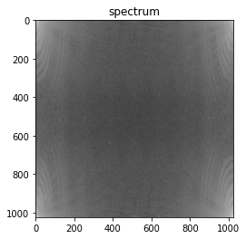

```python
img_c2 = np.fft.fft2(img_c1)
plt.imshow(np.log(1+np.abs(img_c2)),"gray")
plt.title("spectrum")
```

Here you can see that there are white spots over corners which represents the low frequency components.

1. In this step we take the origin from corner to centre. This results in such a way that the centre part contains the low frequency components where as other contains high frequency.

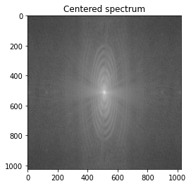

```python
img_c3 = np.fft.fftshift(img_c2)
plt.imshow(np.log(1+np.abs(img_c3)),"gray")
plt.title("Centered spectrum")
```

1. As the next step we are going to decentralise the origin back to where it belong to so that we can convert the image in frequency domain back to what we had.

[figure not shown]

```python
img_c4 = np.fft.ifftshift(img_c3)
plt.imshow(np.log(1+np.abs(img_c3)),"gray")
plt.title("Decentralized")
```

[figure not shown]

```python
img_c1 = cv2.imread('saturn.jpg',0)
plt.imshow(img_c1,"gray")
plt.title("Original Image")
```